# Analyses

KN

2022-11-12

# About

- SPR conducted at Konan University, Jan, 2017
- 77 participants
- Target items:
  - e “OnomatoAspect” 24
  - gano “Temp Loc/Manner gano” 24
- Pure fillers: 48 96 in total

Conditions:  
e (OnomatoAspect)  
a. for x once  
b. for x twice  
c. after x once  
d. after x twice

e 1 a  
1分間|生徒が|ちらっと|黒板を|見たので|先生が|カンニングを|疑った。  
? 生徒は黒板を1分間見た Y  
e 1 b  
1分間|生徒が|ちらちら|黒板を|見たので|先生が|カンニングを|疑った。  
? 生徒は黒板を1分間見た Y  
e 1 c  
1分後|生徒が|ちらっと|黒板を|見たので|先生が|カンニングを|疑った。  
? 生徒は黒板を1分間見た N  
e 1 d  
1分後|生徒が|ちらちら|黒板を|見たので|先生が|カンニングを|疑った。  
? 生徒は黒板を1分間見た N

gano 1 a  
部長の|先月|こっそり|飲んだ|お酒は|取引先からの|差し入れだった。  
? 部長が飲んだお酒は取引先からの差し入れである Y  
gano 1 b  
部長の|先月|会議室で|飲んだ|お酒は|取引先からの|差し入れだった。  
? 部長が飲んだお酒は取引先からの差し入れである Y  
gano 1 c  
部長が|先月|こっそり|飲んだ|お酒は|取引先からの|差し入れだった。  
? 部長が飲んだお酒は取引先からの差し入れである Y  
gano 1 d  
部長が|先月|会議室で|飲んだ|お酒は|取引先からの|差し入れだった。  
? 部長が飲んだお酒は取引先からの差し入れである Y

# Retrieve RT data into alldata

First concatenate all the `.data` files into `alldata.txt`. You can do it in a shell with:

cat *.dat > alldata.txt

##### Load libraries

```r
#library(lme4)
library(lmerTest)
library(plyr)
library(dplyr)
```

```r
library(ggplot2)
library(reshape)
library(gdata)
library(MASS)
```

##### Declare the expt name that is relevant.

```r
ex<-"e"

# critical region
criticalregion<-3

# how far from the critical region do you want the plot to cover?
crplus<-4

# plot labels
ab<-"Durative"
cd<-"Non-durative"
ac<-"Simplex"
bd<-"Reduplicated"

# plot legend（凡例）のならび順はデフォルトではアルファベット順
# 逆順にしたい場合はここを1にする
revorderA <- 1  # ab vs cd
revorderB <- 1  # ac vs bd

# Factor labels in the plots
Alabel<-"Temporal Adv"
Blabel<-"Onomatopoeia"


# Trim incorrectly answered trials?  if( trimincorrect == 1 ){ rt_data<-subset(rt_data,correct==100) }
# No trimming: trimincorrect <- 0
trimincorrect <- 1
```

##### Load data:

```r
alldata<-read.table("alldata.txt",
                 header=FALSE)

colnames(alldata)<-c("subj","expt","item","cond","pos","word","cq","rt")
```

##### Create “spillover” column

#### Be sure that the package dplyr is loaded!!! Otherwise, the lag function won’t work properly

It’s important to create spillover at this point because the order really matters.

```r
# add one element to rt
spilloverraw <- c(0,alldata$rt)
# drop the last element
spilloverraw <- spilloverraw[1:length(spilloverraw)-1]
# add to alldata
alldata$spilloverraw <- spilloverraw

# pos 0 and ? doesn't have a spillover
alldata$spilloverraw<-ifelse(alldata$pos=="0"|alldata$pos=="?",NA,alldata$spilloverraw)
head(alldata)
```

```
##   subj     expt item cond pos     word cq  rt spilloverraw
## 1    1 practice    1    -   0     この  - 438           NA
## 2    1 practice    1    -   1     文は  - 382          438
## 3    1 practice    1    -   2   実験に  - 366          382
## 4    1 practice    1    -   3   慣れて  - 397          366
## 5    1 practice    1    -   4 いただく  - 326          397
## 6    1 practice    1    -   5   ための  - 310          326
```

```r
# centering & standardizing
alldata$spillover<-scale(alldata$spilloverraw, center=T, scale=T)
```

##### Exclude practice items

```r
alldata<-subset(alldata,expt!="practice")
```

##### cq（1/0）を100/0に変換

```r
alldata$cq<-ifelse(alldata$cq=="1",100,ifelse(alldata$cq=="0",0,NA))
```

##### correct columnをcqをもとに作成

```r
# Extract the question rows > select the relevant columns only
cqdata<-subset(alldata,pos=="?") %>%
  dplyr::select(subj,expt,item,cond,cq)

# Rename "cq" as "correct"
names(cqdata)[names(cqdata)=="cq"]<-"correct"


#cqdata<-dplyr::select(cqdata,-cq)

# Merge cqdata with alldata.
alldata <- merge(alldata,cqdata,all=T)

# We don't need cq any longer.  Delete it.
alldata<-dplyr::select(alldata,-cq)
```

# Subject analyses

##### 変数初期化

```r
subjdataframe = c();
```

## RT mean per subject

##### SubjのRT meanを計算して蓄積

```r
tempdata<-alldata[alldata$pos!="?",]
#tapply(tempdata$rt,tempdata$subj,mean)
subjdataframe<-ddply(tempdata,.(subj),summarize,SubjRTmean=mean(rt,na.rm=T))
```

##### Each Subj RT meanのZ-scoreをdataframeに加える

scaleコマンドはデータをstandardize（Z-score変換）してくれる。なおscale(…,scale=F)とするとセンタリングのみ行ってくれる（つまりsdで割らない）。

```r
subjdataframe<-data.frame(subjdataframe, SubjRTZS=scale(subjdataframe$SubjRTmean));
```

##### asterisk columnを加える (outlier indication)

```r
subjdataframe<-data.frame(subjdataframe, RTmark=ifelse(subjdataframe$SubjRTZS>2.5, "*", " "));
```

## Comprehension Accuracy per expt

##### 変数初期化

```r
CAdataframe <- c();
myCA <- c()
myCAdataframe <- c()
```

##### Each exptのComprehension Accuracy情報

```r
CAdataframe<-ddply(alldata,.(expt),summarize,ExptMeanCA=mean(correct,na.rm=T))
```

##### Check data

```r
CAdataframe
```

[output not shown]

## Comprehension Accuracy per subject

##### 変数初期化

```r
CAdataframe <- c();
myCA <- c()
myCAdataframe <- c()
summary(alldata)
```

```
##       subj        expt                item          cond
##  Min.   : 1   Length:64025       Min.   : 1.0   Length:64025
##  1st Qu.:20   Class :character   1st Qu.: 8.0   Class :character
##  Median :39   Mode  :character   Median :16.0   Mode  :character
##  Mean   :39                      Mean   :18.1
##  3rd Qu.:58                      3rd Qu.:24.0
##  Max.   :77                      Max.   :48.0
##
##      pos                word                 rt           spilloverraw
##  Length:64025       Length:64025       Min.   :   31.0   Min.   :   31.0
##  Class :character   Class :character   1st Qu.:  366.0   1st Qu.:  350.0
##  Mode  :character   Mode  :character   Median :  470.0   Median :  446.0
##                                        Mean   :  733.2   Mean   :  581.2
##                                        3rd Qu.:  774.0   3rd Qu.:  630.0
##                                        Max.   :18593.0   Max.   :13590.0
##                                                          NA's   :14784
##    spillover.V1      correct
##  Min.   :-1.170   Min.   :  0.00
##  1st Qu.:-0.505   1st Qu.:100.00
##  Median :-0.304   Median :100.00
##  Mean   :-0.022   Mean   : 75.75
##  3rd Qu.: 0.079   3rd Qu.:100.00
##  Max.   :27.109   Max.   :100.00
##  NA's   :14784
```

##### Each subjのComprehension Accuracy情報を付加

```r
CAdataframe<-ddply(subset(alldata,pos=="?"),.(subj),summarize,SubjCA=mean(correct))
```

##### Merge RT data + CA data

```r
subjdataframe<-merge(subjdataframe,CAdataframe,all=T)
```

##### asteriskを加える (outlier indication)

```r
subjdataframe<-data.frame(subjdataframe, CAmark=ifelse(subjdataframe$SubjCA<200/3, "**", ifelse(subjdataframe$SubjCA<70, "*" , " ")));
```

##### Round the values (for the sake of readability)

(Not used in the actual analyses)

```r
subjrounded <- subjdataframe[c("subj","SubjRTmean","SubjRTZS","RTmark","SubjCA","CAmark")]

subjrounded$SubjRTmean <- round(subjrounded$SubjRTmean,0)
subjrounded$SubjRTZS <- round(subjrounded$SubjRTZS,1)
sdata <- subjrounded

write.csv(sdata,file="subjdata.csv",quote=F)
```

##### Merge RT/CA data with `alldata`

```r
alldata <- merge(alldata,subjdataframe,all=T);
write.csv(alldata,file="alldata.csv",quote=F)
```

##### Check subject data

Note: ak’s comprehension questions are not really questions so this grand mean does not make much sense.

```r
sdata
```

```
##    subj SubjRTmean SubjRTZS RTmark   SubjCA CAmark
## 1     1        622      0.3        81.25000
## 2     2        456     -0.6        85.41667
## 3     3        300     -1.5        72.91667
## 4     4       1134      3.1      * 80.20833
## 5     5        916      1.9        82.29167
## 6     6        775      1.1        85.41667
## 7     7        615      0.2        72.91667
## 8     8        568      0.0        71.87500
## 9     9        546     -0.1        70.83333
## 10   10        837      1.5        81.25000
## 11   11        380     -1.0        72.91667
## 12   12        377     -1.1        63.54167     **
## 13   13        416     -0.8        81.25000
## 14   14        464     -0.6        84.37500
```

[output cut: 63 more lines]

##### Mean, median

```r
mean(subjdataframe$SubjCA)
```

```
## [1] 75.8658
```

```r
median(subjdataframe$SubjCA)
```

```
## [1] 77.08333
```

##### Is there someone with accuracy below 70?

```r
bs <- sdata[which(sdata$SubjCA <70),]
bs[order(bs$SubjCA),]
```

```
##    subj SubjRTmean SubjRTZS RTmark   SubjCA CAmark
## 53   53        365     -1.1        47.91667     **
## 69   69        359     -1.2        62.50000     **
## 48   48        375     -1.1        63.54167     **
## 12   12        377     -1.1        63.54167     **
## 33   33        382     -1.0        64.58333     **
## 39   39        446     -0.7        64.58333     **
## 32   32        404     -0.9        65.62500     **
## 37   37        534     -0.2        65.62500     **
## 41   41        321     -1.4        65.62500     **
## 61   61        366     -1.1        65.62500     **
## 31   31        558     -0.1        67.70833      *
## 70   70        418     -0.8        67.70833      *
## 72   72        724      0.8        67.70833      *
## 59   59        507     -0.4        69.79167      *
```

##### Is there someone with slow mean RT?

```r
bs <- sdata[which(sdata$SubjRTZS >3),]
bs[order(bs$SubjRTmean),]
```

```
##   subj SubjRTmean SubjRTZS RTmark   SubjCA CAmark
## 4    4       1134      3.1      * 80.20833
```

## Comprehension Accuracy per subject x exp

##### 変数初期化

```r
CAdataframe <- c();
myCA <- c()
myCAdataframe <- c()
```

##### Each subjのComprehension Accuracy情報を付加

```r
CAdataframe<-ddply(subset(alldata,pos=="?"),.(expt,subj),summarize,SubjExptCA=mean(correct))
```

```r
ddply(subset(alldata,pos=="?"),.(expt),summarize,ExptCAmean=mean(correct))
```

```
##     expt ExptCAmean
## 1      e   78.46320
## 2 filler   76.08225
## 3   gano   72.83550
```

##### Merge data with `alldata`

```r
alldata <- merge(alldata,CAdataframe,all=T);

# sort when messed up
alldata <- alldata[order(alldata$subj,alldata$expt,alldata$item,alldata$cond,alldata$pos),]
rownames(alldata) <- c(1:nrow(alldata))

write.csv(alldata,file="alldata.csv",quote=F)
```

##### Check subject data

expt x subj

```r
subjexptdata <- CAdataframe[order(CAdataframe$expt,CAdataframe$SubjExptCA),]
# rowname may be messed up; fix it
rownames(subjexptdata) <- c(1:nrow(subjexptdata))
subjexptdata
```

```
##       expt subj SubjExptCA
## 1        e    3   58.33333
## 2        e   32   58.33333
## 3        e   70   58.33333
## 4        e   39   62.50000
## 5        e   53   62.50000
## 6        e    7   66.66667
## 7        e    8   66.66667
## 8        e   12   66.66667
## 9        e   19   66.66667
## 10       e   33   66.66667
## 11       e   41   66.66667
## 12       e   56   66.66667
## 13       e   61   66.66667
## 14       e   64   66.66667
```

[output cut: 217 more lines]

```r
write.csv(subjexptdata,file="subjexptdata.csv",quote=F)
```

##### Is there someone with accuracy below 70?

```r
bs <- subjexptdata[which(subjexptdata$SubjExptCA <70),]
bs[order(bs$expt,bs$SubjExptCA),]
```

```
##       expt subj SubjExptCA
## 1        e    3   58.33333
## 2        e   32   58.33333
## 3        e   70   58.33333
## 4        e   39   62.50000
## 5        e   53   62.50000
## 6        e    7   66.66667
## 7        e    8   66.66667
## 8        e   12   66.66667
## 9        e   19   66.66667
## 10       e   33   66.66667
## 11       e   41   66.66667
## 12       e   56   66.66667
## 13       e   61   66.66667
## 14       e   64   66.66667
```

[output cut: 42 more lines]

# Subj exclusion

##### Who’s slow

```r
sdata[which(sdata$SubjRTZS >3),]
```

```
##   subj SubjRTmean SubjRTZS RTmark   SubjCA CAmark
## 4    4       1134      3.1      * 80.20833
```

##### Comprehension accuracy under 2/3

```r
bs <- subjexptdata[which(subjexptdata$SubjExptCA <70),]
bs[order(bs$expt,bs$SubjExptCA),]
```

```
##       expt subj SubjExptCA
## 1        e    3   58.33333
## 2        e   32   58.33333
## 3        e   70   58.33333
## 4        e   39   62.50000
## 5        e   53   62.50000
## 6        e    7   66.66667
## 7        e    8   66.66667
## 8        e   12   66.66667
## 9        e   19   66.66667
## 10       e   33   66.66667
## 11       e   41   66.66667
## 12       e   56   66.66667
## 13       e   61   66.66667
## 14       e   64   66.66667
```

[output cut: 42 more lines]

```r
sdata[which(sdata$SubjCA < 200/3),]
```

```
##    subj SubjRTmean SubjRTZS RTmark   SubjCA CAmark
## 12   12        377     -1.1        63.54167     **
## 32   32        404     -0.9        65.62500     **
## 33   33        382     -1.0        64.58333     **
## 37   37        534     -0.2        65.62500     **
## 39   39        446     -0.7        64.58333     **
## 41   41        321     -1.4        65.62500     **
## 48   48        375     -1.1        63.54167     **
## 53   53        365     -1.1        47.91667     **
## 61   61        366     -1.1        65.62500     **
## 69   69        359     -1.2        62.50000     **
```

```r
subjexptdata[which(subjexptdata$SubjExptCA < 200/3 & subjexptdata$expt==ex),]
```

```
##   expt subj SubjExptCA
## 1    e    3   58.33333
## 2    e   32   58.33333
## 3    e   70   58.33333
## 4    e   39   62.50000
## 5    e   53   62.50000
```

##### before trimming

Subject number before trimming

```r
unique(alldata$subj)
```

```
##  [1]  1  2  3  4  5  6  7  8  9 10 11 12 13 14 15 16 17 18 19 20 21 22 23 24 25
## [26] 26 27 28 29 30 31 32 33 34 35 36 37 38 39 40 41 42 43 44 45 46 47 48 49 50
## [51] 51 52 53 54 55 56 57 58 59 60 61 62 63 64 65 66 67 68 69 70 71 72 73 74 75
## [76] 76 77
```

```r
length(unique(alldata$subj))
```

```
## [1] 77
```

##### trim by CA

```r
data<-alldata
data<-subset(data,SubjCA>=200/3)
unique(data$subj)
```

```
##  [1]  1  2  3  4  5  6  7  8  9 10 11 13 14 15 16 17 18 19 20 21 22 23 24 25 26
## [26] 27 28 29 30 31 34 35 36 38 40 42 43 44 45 46 47 49 50 51 52 54 55 56 57 58
## [51] 59 60 62 63 64 65 66 67 68 70 71 72 73 74 75 76 77
```

```r
length(unique(data$subj))
```

```
## [1] 67
```

```r
data<-subset(data,SubjExptCA>=0)
unique(data$subj)
```

```
##  [1]  1  2  3  4  5  6  7  8  9 10 11 13 14 15 16 17 18 19 20 21 22 23 24 25 26
## [26] 27 28 29 30 31 34 35 36 38 40 42 43 44 45 46 47 49 50 51 52 54 55 56 57 58
## [51] 59 60 62 63 64 65 66 67 68 70 71 72 73 74 75 76 77
```

```r
length(unique(data$subj))
```

```
## [1] 67
```

##### trim by RTZS

```r
data<-subset(data,SubjRTZS<=99)
unique(data$subj)
```

```
##  [1]  1  2  3  4  5  6  7  8  9 10 11 13 14 15 16 17 18 19 20 21 22 23 24 25 26
## [26] 27 28 29 30 31 34 35 36 38 40 42 43 44 45 46 47 49 50 51 52 54 55 56 57 58
## [51] 59 60 62 63 64 65 66 67 68 70 71 72 73 74 75 76 77
```

```r
length(unique(data$subj))
```

```
## [1] 67
```

##### centering CA

```r
CAdataframe<-ddply(subset(data,pos=="?"),.(subj),summarize,SubjCA=mean(correct))
CAdataframe<-data.frame(CAdataframe,cCA=scale(CAdataframe$SubjCA,scale=F))
```

##### Merge RT data + CA data

```r
data<-merge(data,CAdataframe,all=T)
```

##### centering ExptCA

```r
SubjExptCA<-c()
CAdataframe<-ddply(subset(data,pos=="?"),.(subj,expt),summarize,SubjExptCA=mean(correct))
for(i in unique(CAdataframe$expt)){
  # それぞれのexptのsubj CAmeanを抜き出し
  mySubjExptCA <- CAdataframe[CAdataframe$expt==i,];
  # centering
  mySubjExptCA<-data.frame(mySubjExptCA,cExptCA=scale(mySubjExptCA$SubjExptCA,scale=F))
  # それを蓄積
  SubjExptCA<-rbind(SubjExptCA,mySubjExptCA)
}

data <- merge(data,SubjExptCA,all=T);

# sort when messed up
#data <- data[order(data$subj,data$expt,data$item,data$cond,data$pos),]
#rownames(data) <- c(1:nrow(data))
```

# Isolate the data from the relevant experiment

```r
data<-subset(data,expt==ex)
unique(data$expt)
```

```
## [1] "e"
```

# Reading time summary

##### Omit questions

```r
rt_data<-subset(data,pos!="?")
```

##### Create “region” column from “pos”

`pos` starts from zero and thus is confusing, so create `region` which starts from 1. This is done at this point because `pos` originally contained ? as well as position number. ? is now eliminated. Note: `as.character` gets factors back to characters. I don’t know why but factors cannot get directly back to numeric.

```r
rt_data$region<-as.numeric(as.character(rt_data$pos))+1
```

##### Make sure factors are treated as factors

```r
rt_data$subj<-factor(rt_data$subj)
rt_data$expt<-factor(rt_data$expt)
rt_data$item<-factor(rt_data$item)
rt_data$cond<-factor(rt_data$cond)
rt_data$word<-factor(rt_data$word)
```

##### Correctly answered trials only? (trimincorrect)

Note: if you do this trimming at this point, it precedes the z-score computation.

```r
before <- length(rt_data$rt)
before
```

```
## [1] 12864
```

```r
if( trimincorrect == 1 ){
  rt_data<-subset(rt_data,correct==100)
}
```

```r
after <- length(rt_data$rt)
after
```

```
## [1] 10320
```

```r
(before-after)*100/before
```

```
## [1] 19.77612
```

##### RT trimming?

100msを切るRTが見受けられるのでさすがにカットしたほうが良いかと。

```r
subset(rt_data,rt<200 & region==1,c("expt","cond","region","rt"))
```

```
##       expt cond region  rt
## 15131    e    a      1  77
## 17545    e    d      1  94
## 18350    e    d      1 118
## 18395    e    a      1 183
## 19244    e    d      1 150
## 28389    e    c      1 190
## 28452    e    b      1 151
## 29953    e    c      1 190
## 30142    e    d      1 174
```

```r
subset(rt_data,rt<200 & region==2,c("expt","cond","region","rt"))
```

```
##       expt cond region  rt
## 17654    e    d      2 174
## 18477    e    b      2 190
## 28282    e    c      2 182
## 28453    e    b      2 158
## 39977    e    c      2 198
## 40049    e    c      2 182
## 40067    e    a      2 190
## 40103    e    a      2 198
## 47568    e    a      2 190
```

```r
subset(rt_data,rt<200 & region==3,c("expt","cond","region","rt"))
```

```
##       expt cond region  rt
## 17655    e    d      3 142
## 18352    e    d      3 190
## 18478    e    b      3 174
## 28283    e    c      3 198
## 29955    e    c      3 174
## 30117    e    a      3 182
## 39273    e    c      3 198
## 45780    e    a      3 190
## 45888    e    a      3 198
## 47569    e    a      3 190
```

```r
subset(rt_data,rt<200 & region==4,c("expt","cond","region","rt"))
```

```
##       expt cond region  rt
## 7597     e    c      4 182
## 17530    e    b      4 166
## 17656    e    d      4 102
## 19247    e    d      4 150
## 28392    e    c      4 190
## 30028    e    c      4 182
## 30091    e    b      4 198
## 30145    e    d      4 190
## 40069    e    a      4 198
## 45781    e    a      4 198
## 45808    e    d      4 198
```

```r
subset(rt_data,rt<200 & region==5,c("expt","cond","region","rt"))
```

```
##       expt cond region  rt
## 17468    e    c      5 198
## 17594    e    a      5 158
## 17675    e    b      5  86
## 18354    e    d      5 190
## 29957    e    c      5 182
## 30092    e    b      5 198
## 45746    e    a      5 190
## 45755    e    b      5 198
## 45782    e    a      5 182
## 45791    e    b      5 190
## 45890    e    a      5 190
## 47571    e    a      5 190
```

```r
subset(rt_data,rt>3000 & region==1,c("expt","cond","region","rt"))
```

```
##       expt cond region   rt
## 119      e    b      1 3637
## 10830    e    d      1 7615
## 16650    e    c      1 4182
## 19145    e    a      1 3342
## 23428    e    d      1 8486
## 34969    e    d      1 4390
## 43310    e    a      1 3134
## 43436    e    c      1 3094
## 52547    e    b      1 7886
```

```r
subset(rt_data,rt>3000 & region==2,c("expt","cond","region","rt"))
```

```
##       expt cond region   rt
## 15042    e    c      2 3350
## 19146    e    a      2 8398
## 23303    e    b      2 3806
## 23348    e    c      2 5638
## 23393    e    d      2 3990
## 25805    e    b      2 3710
## 30975    e    d      2 3718
## 31789    e    c      2 3798
## 31798    e    d      2 3054
## 51662    e    c      2 3390
## 52503    e    a      2 3654
## 52548    e    b      2 4990
```

```r
subset(rt_data,rt>3000 & region==3,c("expt","cond","region","rt"))
```

```
##       expt cond region   rt
## 21741    e    a      3 3310
## 23313    e    c      3 3005
## 34266    e    a      3 4286
## 36751    e    c      3 3325
```

```r
subset(rt_data,rt>3000 & region==4,c("expt","cond","region","rt"))
```

```
##       expt cond region   rt
## 35089    e    a      4 3790
```

```r
subset(rt_data,rt>3000 & region==5,c("expt","cond","region","rt"))
```

```
##       expt cond region   rt
## 25157    e    a      5 3582
```

```r
tapply(rt_data$rt, rt_data$region, mean)
```

```
##        1        2        3        4        5        6        7        8
## 619.0581 675.3907 563.0581 499.0380 501.8473 492.2225 463.0240 480.1814
```

```r
tapply(rt_data$rt, paste(rt_data$region, rt_data$cond), mean)
```

```
##      1 a      1 b      1 c      1 d      2 a      2 b      2 c      2 d
## 609.3721 607.2774 617.7273 644.5452 661.6076 645.5701 698.1505 699.6789
##      3 a      3 b      3 c      3 d      4 a      4 b      4 c      4 d
## 569.8866 554.1189 571.3668 556.1438 500.8692 483.2957 507.4734 505.2007
##      5 a      5 b      5 c      5 d      6 a      6 b      6 c      6 d
## 512.1715 488.0976 505.4734 501.1839 523.7297 480.9421 471.4232 490.5385
##      7 a      7 b      7 c      7 d      8 a      8 b      8 c      8 d
## 468.4186 467.0244 456.4953 459.3946 493.6686 471.4085 467.2163 488.1204
```

rt trimming

```r
rt_data_notrim <- rt_data

rt_data<-subset(rt_data_notrim,rt>=150 & rt<=10000)
```

Generate z-scores for variable A using the scale() function scale(A, center = TRUE, scale = TRUE)

```r
myRT <- c()
newdataframe <- c()
for(i in unique(rt_data$region)){
  for(j in unique(rt_data$cond)){
    # abstract rt column in the region x cond cell
    myRT <- subset(rt_data, region==i & cond==j);
    # compute z-score
    myRT$RxCzs <- scale(myRT$rt, center = T, scale = T);
    # 蓄積
    newdataframe<-rbind(newdataframe,myRT);
    }
};

rt_data <- merge(rt_data,newdataframe,all=T)
```

##### check outliers

```r
bs <- rt_data[which(rt_data$RxCzs >3),]
bs <- bs[c("subj","item","region","cond","rt","RxCzs")]
bs[order(bs$region,bs$cond,bs$RxCzs),]
```

```
##       subj item region cond   rt     RxCzs
## 6073    50   12      1    a 1847  3.192658
## 2248    22    4      1    a 1894  3.314054
## 9807    76   18      1    a 1910  3.355380
## 2488    24   14      1    a 1958  3.479359
## 4609     4    6      1    a 2382  4.574508
## 8297    65    9      1    a 3134  6.516847
## 3777    31    3      1    a 3342  7.054090
## 8848     7   24      1    b 2318  3.071334
## 6081    50   13      1    b 2590  3.559667
## 41       1   14      1    b 3637  5.439392
## 9815    76   19      1    b 7886 13.067804
## 3705    31   13      1    c 2142  3.467488
## 5945     5   15      1    c 2206  3.613078
## 4497     4   12      1    c 2342  3.922457
```

[output cut: 185 more lines]

```r
bs <- rt_data[which(rt_data$RxCzs >5),]
bs <- bs[c("subj","item","region","cond","rt","RxCzs")]
bs[order(bs$region,bs$cond,bs$RxCzs),]
```

```
##      subj item region cond   rt     RxCzs
## 8297   65    9      1    a 3134  6.516847
## 3777   31    3      1    a 3342  7.054090
## 41      1   14      1    b 3637  5.439392
## 9815   76   19      1    b 7886 13.067804
## 4625    4    8      1    c 2966  5.341962
## 8241   65   23      1    c 3094  5.633143
## 3382   29    3      1    c 4182  8.108177
## 6825   55    6      1    d 4390  5.187713
## 2240   22    3      1    d 7615  9.658890
## 4537    4   17      1    d 8486 10.866454
## 9784   76   14      2    a 3654  5.034304
## 3778   31    3      2    a 8398 13.015455
## 5114   43    4      2    b 3710  6.022351
## 4594    4    3      2    b 3806  6.211015
```

[output cut: 45 more lines]

##### rt trimming based on RxCzs

```r
tapply(rt_data$rt, paste(rt_data$region, rt_data$cond), mean)
```

```
##      1 a      1 b      1 c      1 d      2 a      2 b      2 c      2 d
## 610.9242 607.2774 617.7273 648.1717 661.6076 645.5701 698.1505 699.6789
##      3 a      3 b      3 c      3 d      4 a      4 b      4 c      4 d
## 569.8866 554.1189 571.3668 557.5336 500.8692 483.2957 507.4734 506.5537
##      5 a      5 b      5 c      5 d      6 a      6 b      6 c      6 d
## 512.1715 489.3272 505.4734 501.1839 523.7297 482.1743 472.4591 490.5385
##      7 a      7 b      7 c      7 d      8 a      8 b      8 c      8 d
## 469.4023 467.0244 456.4953 459.3946 494.7988 471.4085 467.2163 489.4966
```

```r
rt_data<-subset(rt_data,RxCzs<3)

tapply(rt_data$rt, paste(rt_data$region, rt_data$cond), mean)
```

```
##      1 a      1 b      1 c      1 d      2 a      2 b      2 c      2 d
## 574.6429 564.0617 575.4728 585.0884 630.2368 595.2516 642.0767 652.6416
##      3 a      3 b      3 c      3 d      4 a      4 b      4 c      4 d
## 529.4852 514.9687 534.9776 524.7465 481.9618 453.5768 471.8842 481.2389
##      5 a      5 b      5 c      5 d      6 a      6 b      6 c      6 d
## 491.5782 458.6000 478.6262 473.1203 493.4866 452.6994 454.5064 463.4192
##      7 a      7 b      7 c      7 d      8 a      8 b      8 c      8 d
## 446.0564 453.3150 444.9172 441.2774 465.3015 447.6285 445.2283 472.9184
```

```r
(length(rt_data_notrim$rt)-length(rt_data$rt))*100/length(rt_data_notrim$rt)
```

```
## [1] 2.034884
```

## Summary (interim)

のちにtrimmingをする（かもしれない）ので，このファイルの最後でもういちどサマリーとプロットの最終盤を生成します。

##### Extract data for summary

```r
rtg <- subset(rt_data,region<=criticalregion+crplus)
```

##### summary

```r
# Raw rt version
rt_data_summary <- ddply(rtg, .(cond,region), summarise, N=length(rt), mean=mean(rt), sd=sd(rt), se=sd/sqrt(N),ci=qt(0.975,df=N-1)*se)
```

##### Coding conditions for plot labels

```r
rt_data_summary$A<-ifelse(rt_data_summary$cond%in%c("a","b"),ab,cd)
rt_data_summary$B<-ifelse(rt_data_summary$cond%in%c("a","c"),ac,bd)
rt_data_summary$Conditions<-paste(rt_data_summary$A,rt_data_summary$B,sep=":")
rt_data_summary$B
```

```
##  [1] "Simplex"      "Simplex"      "Simplex"      "Simplex"      "Simplex"
##  [6] "Simplex"      "Simplex"      "Reduplicated" "Reduplicated" "Reduplicated"
## [11] "Reduplicated" "Reduplicated" "Reduplicated" "Reduplicated" "Simplex"
## [16] "Simplex"      "Simplex"      "Simplex"      "Simplex"      "Simplex"
## [21] "Simplex"      "Reduplicated" "Reduplicated" "Reduplicated" "Reduplicated"
## [26] "Reduplicated" "Reduplicated" "Reduplicated"
```

```r
# Change the order of the legend labels
if( revorderA == 1 ){
  rt_data_summary$A<-factor(rt_data_summary$A, levels=rev(levels(factor(rt_data_summary$A))))}
if( revorderB == 1 ){
  rt_data_summary$B<-factor(rt_data_summary$B, levels=rev(levels(factor(rt_data_summary$B))))
}


rt_data_summary
```

```
##    cond region   N     mean       sd        se       ci            A
## 1     a      1 336 574.6429 284.8610 15.540440 30.56914     Durative
## 2     a      2 342 630.2368 390.6654 21.124766 41.55126     Durative
## 3     a      3 338 529.4852 261.9268 14.246939 28.02413     Durative
## 4     a      4 340 481.9618 199.2016 10.803222 21.24979     Durative
## 5     a      5 339 491.5782 222.6680 12.093667 23.78833     Durative
## 6     a      6 337 493.4866 213.6102 11.636090 22.88876     Durative
## 7     a      7 337 446.0564 141.3854  7.701752 15.14973     Durative
## 8     b      1 324 564.0617 313.9102 17.439457 34.30926     Durative
## 9     b      2 322 595.2516 329.3920 18.356297 36.11384     Durative
## 10    b      3 319 514.9687 210.1989 11.768876 23.15470     Durative
## 11    b      4 319 453.5768 164.4308  9.206356 18.11306     Durative
## 12    b      5 320 458.6000 192.2022 10.744430 21.13890     Durative
## 13    b      6 316 452.6994 157.9259  8.884026 17.47953     Durative
## 14    b      7 327 453.3150 167.1408  9.242906 18.18327     Durative
```

[output cut: 43 more lines]

```r
#rrt_data_summary
```

## Plots

See the following references for ggplot codes:

http://www.cookbook-r.com/Graphs/Shapes_and_line_types/

http://meme.biology.tohoku.ac.jp/students/iwasaki/rstats/ggplot2.html

##### Raw RT

Base

```r
g <- ggplot(rt_data_summary,aes(x=region,y=mean,group=Conditions))
```

Add lines

```r
g <- g + geom_line(size=1,aes(linetype=A))
g <- g + scale_linetype_manual(values=c("dotdash","solid"))
g <- g + labs(linetype=Alabel)
```

Add points

```r
g <- g + geom_point(size=5,aes(shape=B,fill=B))
g <- g + scale_shape_manual(values=c(21,24,24,25))
g <- g + scale_fill_manual(values=c("white","black","white","black"))
g <- g + labs(shape=Blabel)
g <- g + labs(fill=Blabel)
```

Add error bars

```r
g <- g + geom_errorbar(aes(ymin=mean-se, ymax=mean+se), width=.3)
```

Adjust x-axis breaks and labels

```r
g <- g + scale_x_continuous(breaks=seq(1, 8, by=1),labels=c("Temp Adv", "Subj",
                              "Onom", "Mod", "Verb", "6","7","8"))
```

Create Theme

```r
g <- g + theme(
                 # 背景を消す
                 panel.background = element_rect(fill = "white"),
                 panel.border = element_blank(), axis.line = element_line(),
                 # 凡例の設定
                 legend.position    = c(1, 1),
                 legend.justification = c(1,1),
                 #legend.title = element_blank(),
                 legend.title = element_text(family = "Times", size = 15),
                 legend.text = element_text(size = 15, family="Times"),
                 legend.key = element_blank(),
                 # テキスト形式の設定
                 axis.title.x = element_text(family = "Times", size = 20),
                 axis.title.y = element_text(family = "Times",size = 20),
                 axis.text.x = element_text(angle =   45, size = 15, hjust = 1,family = "Times"),
                 axis.text.y = element_text(size = 15, hjust = 0.5, family = "Times"),
              )
```

Adjust appearance

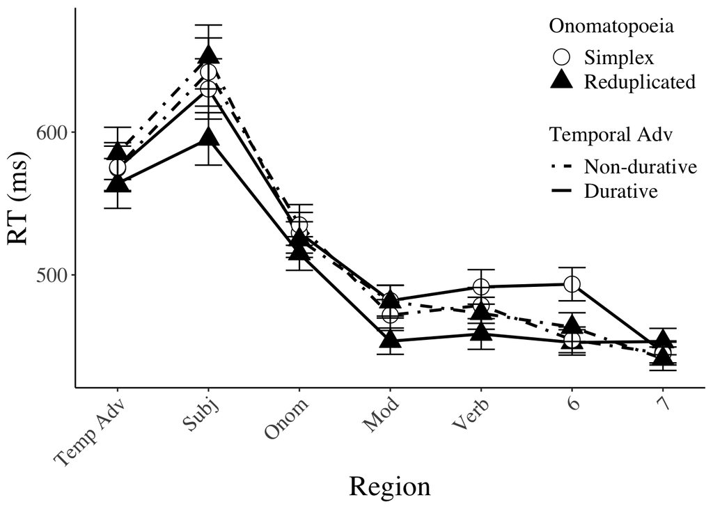

```r
#g <- g + theme_classic(base_size=20, base_family="HiraKakuProN-W3")
#g <- g + theme(base_size=20, base_family="Times", axis.text.x = element_text(angle = 45, hjust = 1))
g <- g + labs(x="Region", y="RT (ms)")
print(g)
```

###### a vs c

```r
gsummary <- subset(rt_data_summary,B==ac)
g <- ggplot(gsummary,aes(x=region,y=mean,group=Conditions))
```

Add lines

```r
g <- g + geom_line(size=1,aes(linetype=B))
g <- g + scale_linetype_manual(values=c("dashed"))
g <- g + labs(linetype=Blabel)
```

Add points

```r
g <- g + geom_point(size=5,aes(shape=A,fill=A))
# 21 (circle), 22 (square), 23 (lozenge), 24 (triangle), 25 (rev triangle)
g <- g + scale_shape_manual(values=c(24,21))
g <- g + scale_fill_manual(values=c("black","white"))
g <- g + labs(shape=Alabel)
g <- g + labs(fill=Alabel)
```

Add error bars

```r
g <- g + geom_errorbar(aes(ymin=mean-se, ymax=mean+se), width=.3)
```

Adjust x-axis breaks

```r
g <- g + scale_x_continuous(breaks=seq(1, 10, by=1))
```

Adjust appearance

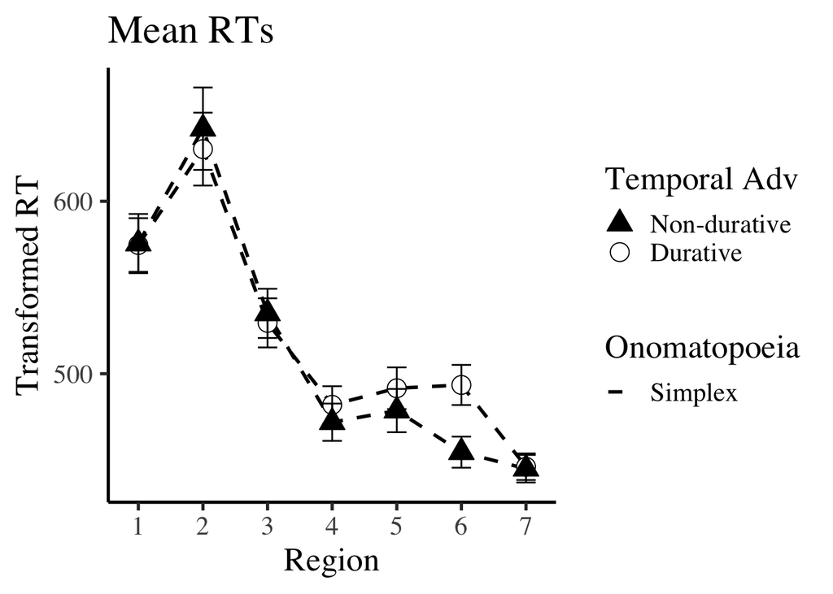

```r
#g <- g + theme_classic(base_size=20, base_family="HiraKakuProN-W3")
g <- g + theme_classic(base_size=20, base_family="Times")
g <- g + labs(x="Region", y="Transformed RT", title="Mean RTs")
print(g)
```

###### b vs d

```r
gsummary <- subset(rt_data_summary,B==bd)
g <- ggplot(gsummary,aes(x=region,y=mean,group=Conditions))
```

Add lines

```r
g <- g + geom_line(size=1,aes(linetype=B))
g <- g + scale_linetype_manual(values=c("solid"))
g <- g + labs(linetype=Blabel)
```

Add points

```r
g <- g + geom_point(size=5,aes(shape=A,fill=A))
# 21 (circle), 22 (square), 23 (lozenge), 24 (triangle), 25 (rev triangle)
g <- g + scale_shape_manual(values=c(24,21))
g <- g + scale_fill_manual(values=c("black","white"))
g <- g + labs(shape=Alabel)
g <- g + labs(fill=Alabel)
```

Add error bars

```r
g <- g + geom_errorbar(aes(ymin=mean-se, ymax=mean+se), width=.3)
```

Adjust x-axis breaks

```r
g <- g + scale_x_continuous(breaks=seq(1, 10, by=1))
```

Adjust appearance

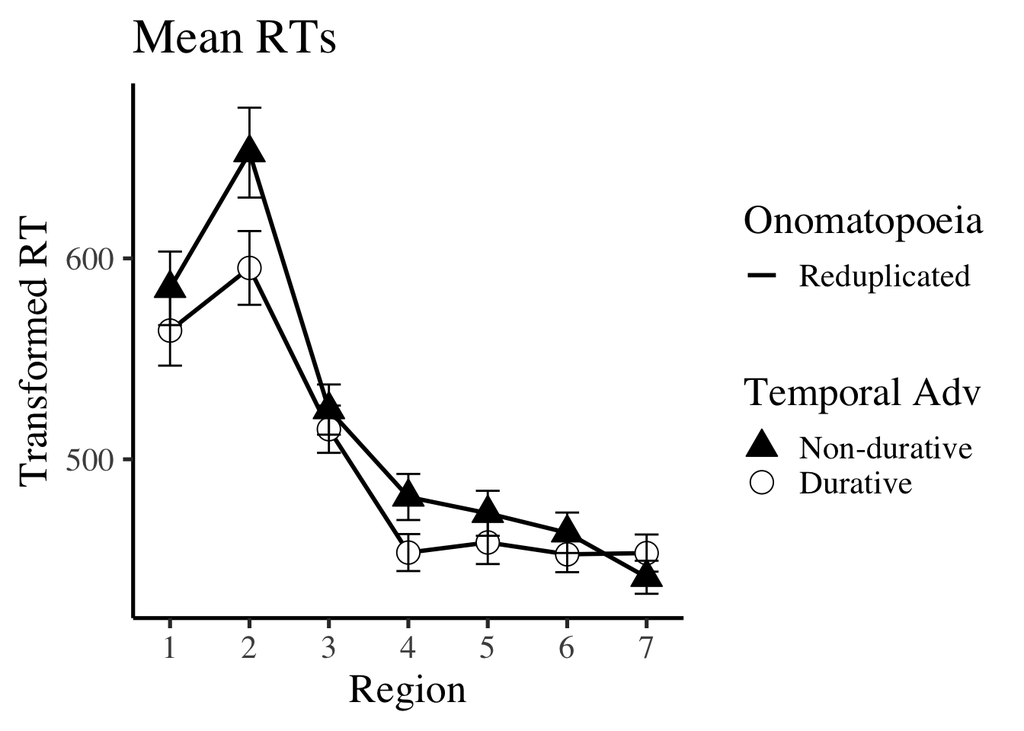

```r
#g <- g + theme_classic(base_size=20, base_family="HiraKakuProN-W3")
g <- g + theme_classic(base_size=20, base_family="Times")
g <- g + labs(x="Region", y="Transformed RT", title="Mean RTs")
print(g)
```

###### a vs b

```r
gsummary <- subset(rt_data_summary,A==ab)
g <- ggplot(gsummary,aes(x=region,y=mean,group=Conditions))
```

Add lines

```r
g <- g + geom_line(size=1,aes(linetype=A))
g <- g + scale_linetype_manual(values=c("solid"))
g <- g + labs(linetype=Alabel)
```

Add points

```r
g <- g + geom_point(size=5,aes(shape=B,fill=B))
# 21 (circle), 22 (square), 23 (lozenge), 24 (triangle), 25 (rev triangle)
g <- g + scale_shape_manual(values=c(24,21))
g <- g + scale_fill_manual(values=c("black","white"))
g <- g + labs(shape=Blabel)
g <- g + labs(fill=Blabel)
```

Add error bars

```r
g <- g + geom_errorbar(aes(ymin=mean-se, ymax=mean+se), width=.3)
```

Adjust x-axis breaks

```r
g <- g + scale_x_continuous(breaks=seq(1, 10, by=1))
```

Adjust appearance

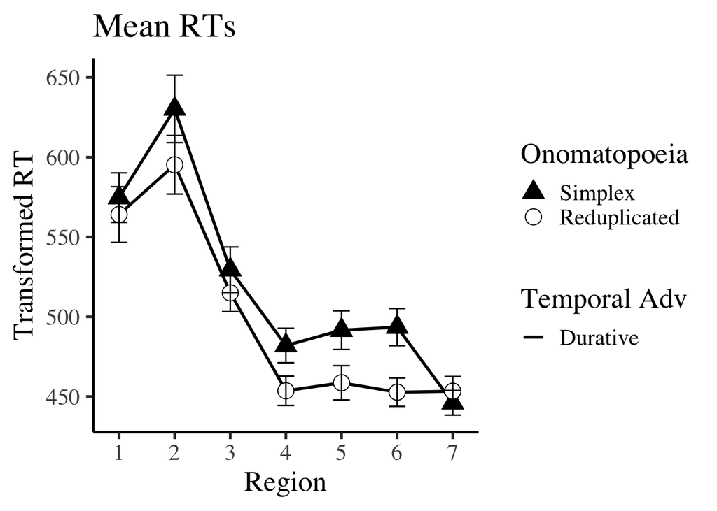

```r
#g <- g + theme_classic(base_size=20, base_family="HiraKakuProN-W3")
g <- g + theme_classic(base_size=20, base_family="Times")
g <- g + labs(x="Region", y="Transformed RT", title="Mean RTs")
print(g)
```

###### c vs d

```r
gsummary <- subset(rt_data_summary,A==cd)
g <- ggplot(gsummary,aes(x=region,y=mean,group=Conditions))
```

Add lines

```r
g <- g + geom_line(size=1,aes(linetype=A))
g <- g + scale_linetype_manual(values=c("dashed"))
g <- g + labs(linetype=Alabel)
```

Add points

```r
g <- g + geom_point(size=5,aes(shape=B,fill=B))
# 21 (circle), 22 (square), 23 (lozenge), 24 (triangle), 25 (rev triangle)
g <- g + scale_shape_manual(values=c(24,21))
g <- g + scale_fill_manual(values=c("black","white"))
g <- g + labs(shape=Blabel)
g <- g + labs(fill=Blabel)
```

Add error bars

```r
g <- g + geom_errorbar(aes(ymin=mean-se, ymax=mean+se), width=.3)
```

Adjust x-axis breaks

```r
g <- g + scale_x_continuous(breaks=seq(1, 10, by=1))
```

Adjust appearance

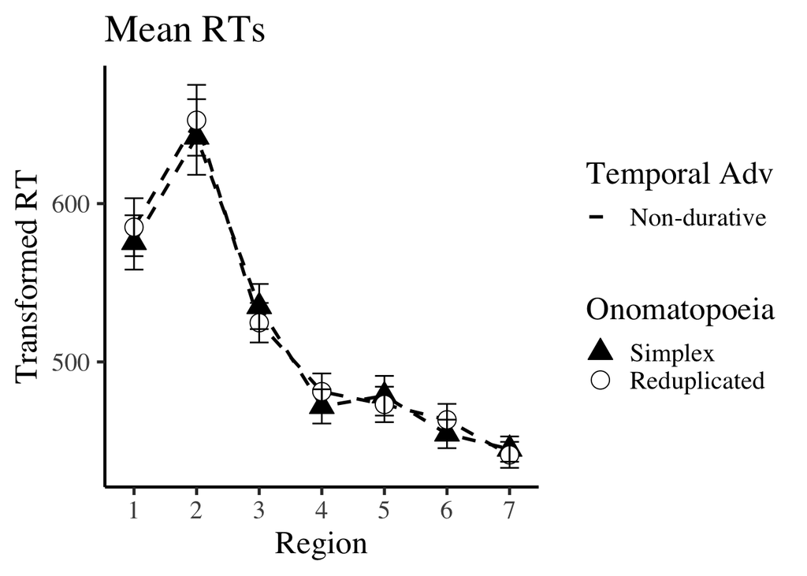

```r
#g <- g + theme_classic(base_size=20, base_family="HiraKakuProN-W3")
g <- g + theme_classic(base_size=20, base_family="Times")
g <- g + labs(x="Region", y="Transformed RT", title="Mean RTs")
print(g)
```

##### Interaction

Base

```r
rtg <- subset(rt_data_summary,region==3)
g <- ggplot(rtg,aes(x=A,y=mean,group=Conditions))
```

Add lines

```r
g <- g + geom_line(size=1,aes(group=B,linetype=B))
g <- g + scale_linetype_manual(values=c("dotdash","solid"))
g <- g + labs(linetype=Blabel)
```

Add points

```r
g <- g + geom_point(size=8,aes(shape=B,fill=B))
g <- g + scale_shape_manual(values=c(21,24,24,25))
g <- g + scale_fill_manual(values=c("white","black","white","black"))
g <- g + labs(shape=Blabel)
g <- g + labs(fill=Blabel)
```

Add error bars

```r
g <- g + geom_errorbar(aes(ymin=mean-ci, ymax=mean+ci), width=.1)
```

Adjust x-axis breaks

```r
#g <- g + scale_x_continuous(breaks=seq(1, 10, by=1))
```

Adjust appearance

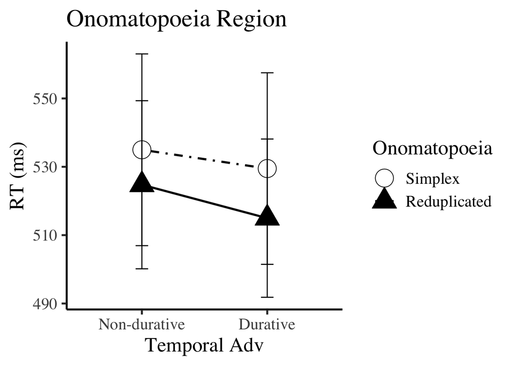

```r
#g <- g + theme_classic(base_size=20, base_family="HiraKakuProN-W3")
g <- g + theme_classic(base_size=20, base_family="Times")
g <- g + labs(x="Temporal Adv", y="RT (ms)", title="Onomatopoeia Region")
print(g)
```

##### Interaction

Base

```r
rtg <- subset(rt_data_summary,region==4)
g <- ggplot(rtg,aes(x=A,y=mean,group=Conditions))
```

Add lines

```r
g <- g + geom_line(size=1,aes(group=B,linetype=B))
g <- g + scale_linetype_manual(values=c("dotdash","solid"))
g <- g + labs(linetype=Blabel)
```

Add points

```r
g <- g + geom_point(size=8,aes(shape=B,fill=B))
g <- g + scale_shape_manual(values=c(21,24,24,25))
g <- g + scale_fill_manual(values=c("white","black","white","black"))
g <- g + labs(shape=Blabel)
g <- g + labs(fill=Blabel)
```

Add error bars

```r
g <- g + geom_errorbar(aes(ymin=mean-ci, ymax=mean+ci), width=.1)
```

Adjust x-axis breaks

```r
#g <- g + scale_x_continuous(breaks=seq(1, 10, by=1))
```

Adjust appearance

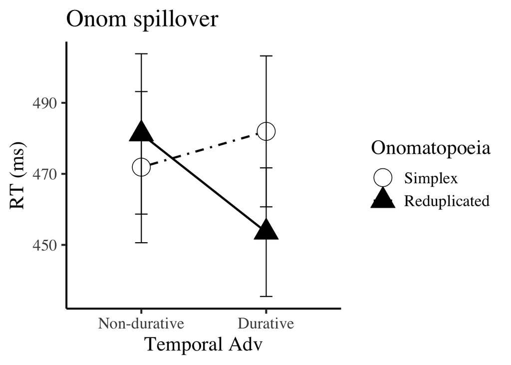

```r
#g <- g + theme_classic(base_size=20, base_family="HiraKakuProN-W3")
g <- g + theme_classic(base_size=20, base_family="Times")
g <- g + labs(x="Temporal Adv", y="RT (ms)", title="Onom spillover")
print(g)
```

##### Interaction

Base

```r
rtg <- subset(rt_data_summary,region==5)
g <- ggplot(rtg,aes(x=A,y=mean,group=Conditions))
```

Add lines

```r
g <- g + geom_line(size=1,aes(group=B,linetype=B))
g <- g + scale_linetype_manual(values=c("dotdash","solid"))
g <- g + labs(linetype=Blabel)
```

Add points

```r
g <- g + geom_point(size=8,aes(shape=B,fill=B))
g <- g + scale_shape_manual(values=c(21,24,24,25))
g <- g + scale_fill_manual(values=c("white","black","white","black"))
g <- g + labs(shape=Blabel)
g <- g + labs(fill=Blabel)
```

Add error bars

```r
g <- g + geom_errorbar(aes(ymin=mean-ci, ymax=mean+ci), width=.1)
```

Adjust x-axis breaks

```r
#g <- g + scale_x_continuous(breaks=seq(1, 10, by=1))
```

Adjust appearance

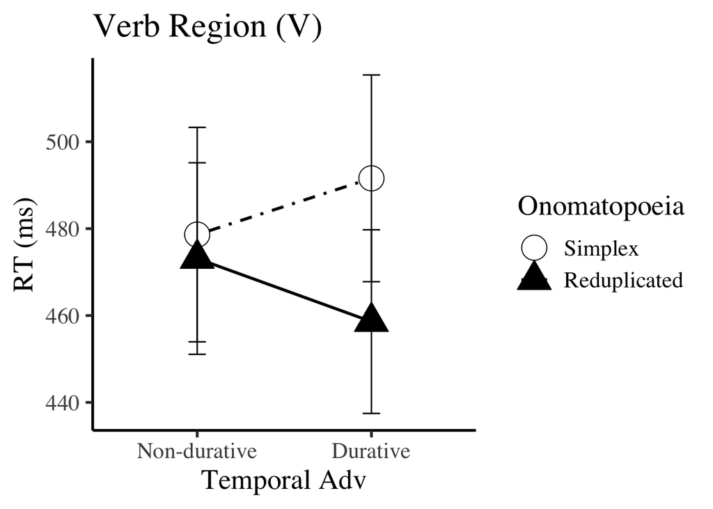

```r
#g <- g + theme_classic(base_size=20, base_family="HiraKakuProN-W3")
g <- g + theme_classic(base_size=20, base_family="Times")
g <- g + labs(x="Temporal Adv", y="RT (ms)", title="Verb Region (V)")
print(g)
```

##### Interaction

Base

```r
rtg <- subset(rt_data_summary,region==6)
g <- ggplot(rtg,aes(x=A,y=mean,group=Conditions))
```

Add lines

```r
g <- g + geom_line(size=1,aes(group=B,linetype=B))
g <- g + scale_linetype_manual(values=c("dotdash","solid"))
g <- g + labs(linetype=Blabel)
```

Add points

```r
g <- g + geom_point(size=8,aes(shape=B,fill=B))
g <- g + scale_shape_manual(values=c(21,24,24,25))
g <- g + scale_fill_manual(values=c("white","black","white","black"))
g <- g + labs(shape=Blabel)
g <- g + labs(fill=Blabel)
```

Add error bars

```r
g <- g + geom_errorbar(aes(ymin=mean-ci, ymax=mean+ci), width=.1)
```

Adjust x-axis breaks

```r
#g <- g + scale_x_continuous(breaks=seq(1, 10, by=1))
```

Adjust appearance

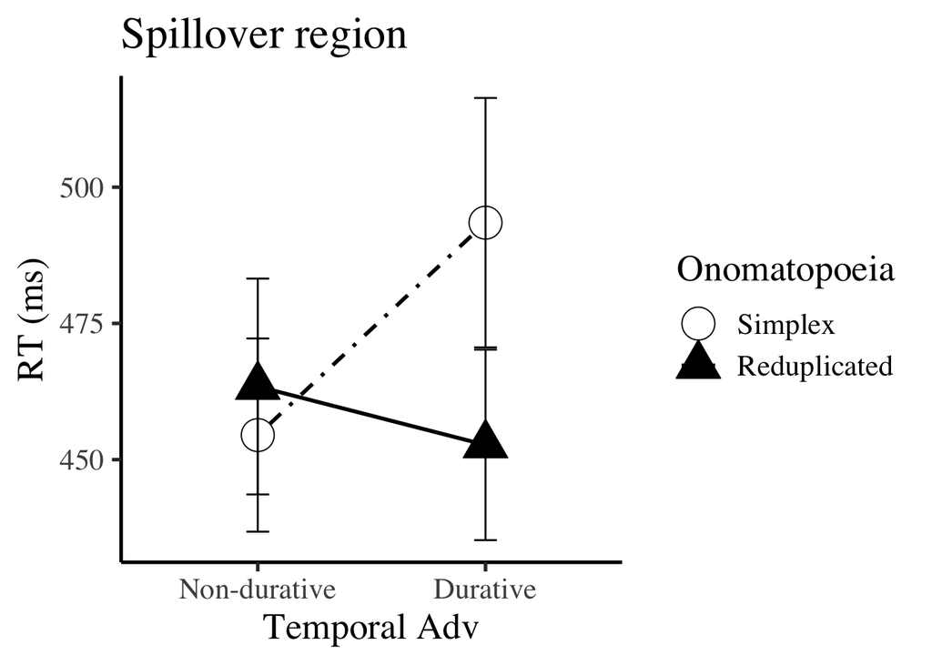

```r
#g <- g + theme_classic(base_size=20, base_family="HiraKakuProN-W3")
g <- g + theme_classic(base_size=20, base_family="Times")
g <- g + labs(x="Temporal Adv", y="RT (ms)", title="Spillover region")
print(g)
```

# Analyses

## Coding factors (with centering)

##### CONDITIONS:

```r
rt_data$adv<-ifelse(rt_data$cond%in%c("a","b"),1,-1)
rt_data$onom<-ifelse(rt_data$cond%in%c("a","c"),1,-1)
rt_data$int<-rt_data$adv*rt_data$onom

# For pairwise comparisons
rt_data$simplexVSredup_dur <-ifelse(rt_data$adv==1,
                          ifelse(rt_data$onom==1,1,-1),
                          0)
rt_data$simplexVSredup_nondur <-ifelse(rt_data$adv==-1,
                          ifelse(rt_data$onom==1,1,-1),
                          0)
rt_data$durVSnondur_simplex <-ifelse(rt_data$onom==1,
                          ifelse(rt_data$adv==1,1,-1),
                          0)
rt_data$durVSnondur_redup <-ifelse(rt_data$onom==-1,
                          ifelse(rt_data$adv==1,1,-1),
                          0)
```

rt_data check

```r
dc <- subset(rt_data,cond=="a",c(cond,word,adv,onom,int))
head(dc, n=7)
```

```
##   cond         word adv onom int
## 1    a        1分間   1    1   1
## 2    a       生徒が   1    1   1
## 3    a     ちらっと   1    1   1
## 4    a       黒板を   1    1   1
## 5    a     見たので   1    1   1
## 6    a       先生が   1    1   1
## 7    a カンニングを   1    1   1
```

```r
dc <- subset(rt_data,cond=="b",c(cond,word,adv,onom,int))
head(dc, n=7)
```

```
##    cond       word adv onom int
## 9     b      1分間   1   -1  -1
## 10    b       傷が   1   -1  -1
## 11    b   ずきずき   1   -1  -1
## 12    b 刺すように   1   -1  -1
## 13    b 痛んだので   1   -1  -1
## 14    b   午前中に   1   -1  -1
## 15    b     病院へ   1   -1  -1
```

```r
dc <- subset(rt_data,cond=="c",c(cond,word,adv,onom,int))
head(dc, n=7)
```

```
##    cond         word adv onom int
## 17    c        1分後  -1    1  -1
## 18    c     小学生が  -1    1  -1
## 19    c     ぱらっと  -1    1  -1
## 20    c     教科書を  -1    1  -1
## 21    c めくったので  -1    1  -1
## 22    c         紙が  -1    1  -1
## 23    c       机から  -1    1  -1
```

```r
dc <- subset(rt_data,cond=="d",c(cond,word,adv,onom,int))
head(dc, n=7)
```

```
##    cond       word adv onom int
## 25    d     30分後  -1   -1   1
## 26    d その老人が  -1   -1   1
## 27    d   ざくざく  -1   -1   1
## 28    d   玉ねぎを  -1   -1   1
## 29    d 切ったので  -1   -1   1
## 30    d       目が  -1   -1   1
## 31    d     かなり  -1   -1   1
```

##### Make sure factors are treated as factors

```r
rt_data$subj<-factor(rt_data$subj)
rt_data$expt<-factor(rt_data$expt)
rt_data$item<-factor(rt_data$item)
rt_data$cond<-factor(rt_data$cond)
rt_data$word<-factor(rt_data$word)
```

#### Critical region

```r
cregion<-subset(rt_data,region==criticalregion)
```

##### Check words

```r
sort(unique(cregion$word))
```

```
##  [1] ガチャンガチャンと ガチャンと         キュキュッと       キュッと
##  [5] ぐさぐさ           ぐさっと           ぐらぐら           ぐらっと
##  [9] クルクル           ぐるぐる           クルッと           ぐるっと
## [13] ごほごほ           ごほっと           ざくざく           ざくっと
## [17] ずきずき           ずきっと           ズルズル           ズルッと
## [21] ちらちら           ちらっと           ぱしゃっと         ぱしゃぱしゃ
## [25] ばたっと           ばたばた           バタンと           バタンバタン
## [29] ぱちっと           ぱちぱち           ぱらっと           ぱらぱら
## [33] バンッと           パンッと           バンバンと         パンパンと
## [37] ぴかっと           ぴかぴか           ピョンと           ピョンピョン
## [41] ぶんっと           ぶんぶん           ぺこっと           ぺこぺこ
## [45] ぺたっと           ぺたぺた           ボキッと           ボキボキ
## 202 Levels: 10分後 10分間 10秒後 10秒間 1分後 1分間 30分後 30分間 ... 鼻を
```

##### Max model

```r
mm<-lmer(rt~adv*onom+
           (1+adv*onom|subj)+(1+adv*onom|item),
           control=lmerControl(optimizer="bobyqa"),
           cregion)
```

```
## boundary (singular) fit: see help('isSingular')
```

```r
summary(mm)
```

```
## Linear mixed model fit by REML. t-tests use Satterthwaite's method [
## lmerModLmerTest]
## Formula: rt ~ adv * onom + (1 + adv * onom | subj) + (1 + adv * onom |
##     item)
##    Data: cregion
## Control: lmerControl(optimizer = "bobyqa")
##
## REML criterion at convergence: 16894.9
##
## Scaled residuals:
##     Min      1Q  Median      3Q     Max
## -3.3930 -0.5486 -0.1882  0.3031  5.2631
##
## Random effects:
##  Groups   Name        Variance Std.Dev. Corr
##  subj     (Intercept) 19637.16 140.133
##           adv           780.64  27.940  -0.24
##           onom          677.07  26.021   0.67  0.13
##           adv:onom      672.60  25.935   0.00  0.91  0.52
##  item     (Intercept)   267.52  16.356
##           adv            14.74   3.839   0.49
##           onom          289.44  17.013   0.75  0.94
##           adv:onom       97.48   9.873  -0.53 -1.00 -0.96
##  Residual             33782.15 183.799
## Number of obs: 1258, groups:  subj, 67; item, 24
##
## Fixed effects:
##             Estimate Std. Error      df t value Pr(>|t|)
## (Intercept)  525.749     18.227  66.853  28.844   <2e-16 ***
## adv           -4.717      6.321  63.848  -0.746    0.458
## onom           6.224      7.079  24.476   0.879    0.388
## adv:onom      -1.201      6.469  43.950  -0.186    0.854
## ---
## Signif. codes:  0 '***' 0.001 '**' 0.01 '*' 0.05 '.' 0.1 ' ' 1
##
## Correlation of Fixed Effects:
##          (Intr) adv    onom
## adv      -0.122
## onom      0.344  0.095
## adv:onom -0.031  0.180 -0.068
## optimizer (bobyqa) convergence code: 0 (OK)
## boundary (singular) fit: see help('isSingular')
```

```r
(step_res <- step(mm, reduce.fixed = F))
```

```
## boundary (singular) fit: see help('isSingular')
```

```
## boundary (singular) fit: see help('isSingular')
## boundary (singular) fit: see help('isSingular')
## boundary (singular) fit: see help('isSingular')
```

[output not shown]

```
## Backward reduced random-effect table:
##
##                                     Eliminated npar  logLik   AIC     LRT Df
## <none>                                           25 -8447.5 16945
## adv:onom in (1 + adv * onom | item)          1   21 -8448.1 16938  1.2268  4
## adv in (adv + onom | item)                   2   18 -8448.1 16932  0.0533  3
## onom in (onom | item)                        3   16 -8448.8 16930  1.3243  2
## (1 | item)                                   4   15 -8449.2 16928  0.7749  1
## adv:onom in (1 + adv * onom | subj)          0   11 -8457.0 16936 15.6700  4
##                                     Pr(>Chisq)
## <none>
## adv:onom in (1 + adv * onom | item)   0.873662
## adv in (adv + onom | item)            0.996781
## onom in (onom | item)                 0.515739
## (1 | item)                            0.378708
## adv:onom in (1 + adv * onom | subj)   0.003496 **
## ---
## Signif. codes:  0 '***' 0.001 '**' 0.01 '*' 0.05 '.' 0.1 ' ' 1
##
## Backward reduced fixed-effect table:
## Degrees of freedom method: Satterthwaite
##
##          Eliminated Sum Sq Mean Sq NumDF  DenDF F value Pr(>F)
## adv:onom          0 1166.6  1166.6     1 88.062  0.0341 0.8539
##
## Model found:
## rt ~ adv + onom + (1 + adv * onom | subj) + adv:onom
```

```r
final <- get_model(step_res)
summary(final)
```

```
## Linear mixed model fit by REML. t-tests use Satterthwaite's method [
## lmerModLmerTest]
## Formula: rt ~ adv + onom + (1 + adv * onom | subj) + adv:onom
##    Data: cregion
## Control: lmerControl(optimizer = "bobyqa")
##
## REML criterion at convergence: 16898.3
##
## Scaled residuals:
##     Min      1Q  Median      3Q     Max
## -3.4286 -0.5518 -0.2019  0.2995  5.3933
##
## Random effects:
##  Groups   Name        Variance Std.Dev. Corr
##  subj     (Intercept) 19573.5  139.91
##           adv           923.6   30.39   -0.23
##           onom          620.0   24.90    0.68  0.11
##           adv:onom      845.4   29.08   -0.01  0.93  0.45
##  Residual             34225.0  185.00
## Number of obs: 1258, groups:  subj, 67
##
## Fixed effects:
##             Estimate Std. Error      df t value Pr(>|t|)
## (Intercept)  525.739     17.888  65.780  29.390   <2e-16 ***
## adv           -4.533      6.447  78.603  -0.703    0.484
## onom           6.362      6.083  72.239   1.046    0.299
## adv:onom      -1.174      6.357  88.062  -0.185    0.854
## ---
## Signif. codes:  0 '***' 0.001 '**' 0.01 '*' 0.05 '.' 0.1 ' ' 1
##
## Correlation of Fixed Effects:
##          (Intr) adv    onom
## adv      -0.137
## onom      0.315  0.036
## adv:onom -0.004  0.278  0.092
## optimizer (bobyqa) convergence code: 0 (OK)
## boundary (singular) fit: see help('isSingular')
```

```r
anova(final)
```

```
## Type III Analysis of Variance Table with Satterthwaite's method
##          Sum Sq Mean Sq NumDF  DenDF F value Pr(>F)
## adv       16920   16920     1 78.603  0.4944 0.4841
## onom      37432   37432     1 72.239  1.0937 0.2991
## adv:onom   1167    1167     1 88.062  0.0341 0.8539
```

#### Critical region +

```r
cr <- criticalregion +1
cregion<-subset(rt_data,region==cr)
```

##### Check words

```r
sort(unique(cregion$word))
```

```
##  [1] シールを     しんどそうに ハードルを   バットを     まぶしそうに
##  [6] 丁寧に       写真を       刺すように   大きく       扉を
## [11] 手を         指を         教科書を     犯人に       玉ねぎを
## [16] 生地を       皿を         肉を         舞台で       花瓶を
## [21] 道路に       遠くで       黒板を       鼻を
## 202 Levels: 10分後 10分間 10秒後 10秒間 1分後 1分間 30分後 30分間 ... 鼻を
```

##### Max model

```r
mm<-lmer(rt~adv*onom+
           (1+adv*onom|subj)+(1+adv*onom|item),
           control=lmerControl(optimizer="bobyqa"),
           cregion)
```

```
## boundary (singular) fit: see help('isSingular')
```

```r
summary(mm)
```

```
## Linear mixed model fit by REML. t-tests use Satterthwaite's method [
## lmerModLmerTest]
## Formula: rt ~ adv * onom + (1 + adv * onom | subj) + (1 + adv * onom |
##     item)
##    Data: cregion
## Control: lmerControl(optimizer = "bobyqa")
##
## REML criterion at convergence: 16414.8
##
## Scaled residuals:
##     Min      1Q  Median      3Q     Max
## -3.2719 -0.5876 -0.1961  0.2711  5.2001
##
## Random effects:
##  Groups   Name        Variance  Std.Dev. Corr
##  subj     (Intercept) 12639.162 112.424
##           adv            57.449   7.580  -0.53
##           onom          258.201  16.069   0.26 -0.32
##           adv:onom      316.502  17.791   0.63  0.30 -0.16
##  item     (Intercept)   739.850  27.200
##           adv            46.223   6.799  -0.49
##           onom          104.784  10.236  -0.69 -0.29
##           adv:onom        4.919   2.218  -0.31 -0.68  0.90
##  Residual             22196.219 148.984
## Number of obs: 1263, groups:  subj, 67; item, 24
##
## Fixed effects:
##             Estimate Std. Error      df t value Pr(>|t|)
## (Intercept)  473.097     15.436  74.074  30.648   <2e-16 ***
## adv           -5.020      4.587  50.631  -1.094    0.279
## onom           6.164      5.141  30.575   1.199    0.240
## adv:onom       6.855      4.810  68.349   1.425    0.159
## ---
## Signif. codes:  0 '***' 0.001 '**' 0.01 '*' 0.05 '.' 0.1 ' ' 1
##
## Correlation of Fixed Effects:
##          (Intr) adv    onom
## adv      -0.165
## onom     -0.024 -0.061
## adv:onom  0.245 -0.025 -0.032
## optimizer (bobyqa) convergence code: 0 (OK)
## boundary (singular) fit: see help('isSingular')
```

```r
(step_res <- step(mm, reduce.fixed = F))
```

```
## boundary (singular) fit: see help('isSingular')
## boundary (singular) fit: see help('isSingular')
## boundary (singular) fit: see help('isSingular')
## boundary (singular) fit: see help('isSingular')
```

[output not shown]

```
## boundary (singular) fit: see help('isSingular')
## boundary (singular) fit: see help('isSingular')
```

```
## boundary (singular) fit: see help('isSingular')
## boundary (singular) fit: see help('isSingular')
```

```
## Backward reduced random-effect table:
##
##                                     Eliminated npar  logLik   AIC    LRT Df
## <none>                                           25 -8207.4 16465
## adv:onom in (1 + adv * onom | item)          1   21 -8207.5 16457   0.10  4
## adv in (adv + onom | item)                   2   18 -8207.8 16452   0.76  3
## onom in (onom | item)                        3   16 -8209.1 16450   2.57  2
## adv:onom in (1 + adv * onom | subj)          4   12 -8212.5 16449   6.84  4
## adv in (adv + onom | subj)                   5    9 -8213.0 16444   0.87  3
## onom in (onom | subj)                        6    7 -8214.0 16442   2.00  2
## (1 | item)                                   0    6 -8221.7 16455  15.45  1
## (1 | subj)                                   0    6 -8392.6 16797 357.21  1
##                                     Pr(>Chisq)
## <none>
## adv:onom in (1 + adv * onom | item)     0.9988
## adv in (adv + onom | item)              0.8600
## onom in (onom | item)                   0.2769
## adv:onom in (1 + adv * onom | subj)     0.1449
## adv in (adv + onom | subj)              0.8319
## onom in (onom | subj)                   0.3671
## (1 | item)                           8.456e-05 ***
## (1 | subj)                           < 2.2e-16 ***
## ---
## Signif. codes:  0 '***' 0.001 '**' 0.01 '*' 0.05 '.' 0.1 ' ' 1
##
## Backward reduced fixed-effect table:
## Degrees of freedom method: Satterthwaite
##
##          Eliminated Sum Sq Mean Sq NumDF  DenDF F value Pr(>F)
## adv:onom          0  55379   55379     1 1183.8  2.4075  0.121
##
## Model found:
## rt ~ adv + onom + (1 | item) + (1 | subj) + adv:onom
```

```r
final <- get_model(step_res)
summary(final)
```

```
## Linear mixed model fit by REML. t-tests use Satterthwaite's method [
## lmerModLmerTest]
## Formula: rt ~ adv + onom + (1 | item) + (1 | subj) + adv:onom
##    Data: cregion
## Control: lmerControl(optimizer = "bobyqa")
##
## REML criterion at convergence: 16428
##
## Scaled residuals:
##     Min      1Q  Median      3Q     Max
## -3.0052 -0.5677 -0.2004  0.3018  5.1946
##
## Random effects:
##  Groups   Name        Variance Std.Dev.
##  subj     (Intercept) 12819.4  113.22
##  item     (Intercept)   679.5   26.07
##  Residual             23003.0  151.67
## Number of obs: 1263, groups:  subj, 67; item, 24
##
## Fixed effects:
##             Estimate Std. Error       df t value Pr(>|t|)
## (Intercept)  473.218     15.457   73.661  30.614   <2e-16 ***
## adv           -5.537      4.321 1186.061  -1.281    0.200
## onom           6.372      4.309 1180.937   1.479    0.140
## adv:onom       6.705      4.321 1183.802   1.552    0.121
## ---
## Signif. codes:  0 '***' 0.001 '**' 0.01 '*' 0.05 '.' 0.1 ' ' 1
##
## Correlation of Fixed Effects:
##          (Intr) adv    onom
## adv      -0.014
## onom     -0.009 -0.001
## adv:onom  0.002 -0.036 -0.047
```

```r
anova(final)
```

```
## Type III Analysis of Variance Table with Satterthwaite's method
##          Sum Sq Mean Sq NumDF  DenDF F value Pr(>F)
## adv       37774   37774     1 1186.1  1.6421 0.2003
## onom      50287   50287     1 1180.9  2.1861 0.1395
## adv:onom  55379   55379     1 1183.8  2.4075 0.1210
```

#### Critical region ++

```r
cr <- criticalregion +2
cregion<-subset(rt_data,region==cr)
```

##### Check words

```r
sort(unique(cregion$word))
```

```
##  [1] お辞儀したので   すすったので     まばたきしたので めくったので
##  [5] 倒れたので       光ったので       切ったので       刺したので
##  [9] 割ったので       叩いたので       咳こんだので     回ったので
## [13] 拭いたので       振ったので       揺れたので       撮ったので
## [17] 混ぜたので       痛んだので       発砲したので     見たので
## [21] 貼ったので       閉めたので       飛び越えたので   鳴らしたので
## 202 Levels: 10分後 10分間 10秒後 10秒間 1分後 1分間 30分後 30分間 ... 鼻を
```

##### Max model

```r
mm<-lmer(rt~adv*onom+
           (adv*onom+1|subj)+(adv*onom+1|item),
           control=lmerControl(optimizer="bobyqa"),
           cregion)
```

```
## boundary (singular) fit: see help('isSingular')
```

```r
summary(mm)
```

```
## Linear mixed model fit by REML. t-tests use Satterthwaite's method [
## lmerModLmerTest]
## Formula: rt ~ adv * onom + (adv * onom + 1 | subj) + (adv * onom + 1 |
##     item)
##    Data: cregion
## Control: lmerControl(optimizer = "bobyqa")
##
## REML criterion at convergence: 16688.5
##
## Scaled residuals:
##     Min      1Q  Median      3Q     Max
## -3.0353 -0.5497 -0.2082  0.2825  4.1729
##
## Random effects:
##  Groups   Name        Variance Std.Dev. Corr
##  subj     (Intercept) 14222.82 119.259
##           adv           836.01  28.914  -0.18
##           onom          820.67  28.647   0.52 -0.65
##           adv:onom      405.45  20.136   0.12  0.46  0.34
##  item     (Intercept)   449.22  21.195
##           adv           310.65  17.625   0.89
##           onom          174.52  13.210  -0.54 -0.67
##           adv:onom       25.55   5.055   0.72  0.93 -0.83
##  Residual             26816.93 163.759
## Number of obs: 1263, groups:  subj, 67; item, 24
##
## Fixed effects:
##             Estimate Std. Error      df t value Pr(>|t|)
## (Intercept)  475.710     15.923  69.465  29.875   <2e-16 ***
## adv           -1.505      6.914  25.610  -0.218    0.829
## onom           9.391      6.452  32.853   1.456    0.155
## adv:onom       4.021      5.405  61.003   0.744    0.460
## ---
## Signif. codes:  0 '***' 0.001 '**' 0.01 '*' 0.05 '.' 0.1 ' ' 1
##
## Correlation of Fixed Effects:
##          (Intr) adv    onom
## adv       0.037
## onom      0.189 -0.329
## adv:onom  0.090  0.182 -0.012
## optimizer (bobyqa) convergence code: 0 (OK)
## boundary (singular) fit: see help('isSingular')
```

```r
(step_res <- step(mm, reduce.fixed = F))
```

[output not shown]

```
## Backward reduced random-effect table:
##
##                                     Eliminated npar  logLik   AIC     LRT Df
## <none>                                           25 -8344.2 16738
## adv:onom in (adv * onom + 1 | item)          1   21 -8344.5 16731  0.6305  4
## onom in (adv + onom | item)                  2   18 -8345.7 16727  2.2211  3
## adv:onom in (adv * onom + 1 | subj)          3   14 -8348.4 16725  5.4530  4
## adv in (adv | item)                          0   12 -8356.4 16737 16.1046  2
## adv in (adv + onom | subj)                   0   11 -8354.2 16730 11.6591  3
## onom in (adv + onom | subj)                  0   11 -8356.6 16735 16.4258  3
##                                     Pr(>Chisq)
## <none>
## adv:onom in (adv * onom + 1 | item)  0.9596141
## onom in (adv + onom | item)          0.5278072
## adv:onom in (adv * onom + 1 | subj)  0.2438906
## adv in (adv | item)                  0.0003184 ***
## adv in (adv + onom | subj)           0.0086469 **
## onom in (adv + onom | subj)          0.0009274 ***
## ---
## Signif. codes:  0 '***' 0.001 '**' 0.01 '*' 0.05 '.' 0.1 ' ' 1
##
## Backward reduced fixed-effect table:
## Degrees of freedom method: Satterthwaite
##
##          Eliminated Sum Sq Mean Sq NumDF  DenDF F value Pr(>F)
## adv:onom          0  19618   19618     1 1096.4  0.7097 0.3997
##
## Model found:
## rt ~ adv + onom + (adv | item) + (adv + onom | subj) + adv:onom
```

```r
final <- get_model(step_res)
summary(final)
```

```
## Linear mixed model fit by REML. t-tests use Satterthwaite's method [
## lmerModLmerTest]
## Formula: rt ~ adv + onom + (adv | item) + (adv + onom | subj) + adv:onom
##    Data: cregion
## Control: lmerControl(optimizer = "bobyqa")
##
## REML criterion at convergence: 16696.8
##
## Scaled residuals:
##     Min      1Q  Median      3Q     Max
## -2.8896 -0.5572 -0.2109  0.2659  4.3482
##
## Random effects:
##  Groups   Name        Variance Std.Dev. Corr
##  subj     (Intercept) 14184.7  119.10
##           adv           810.0   28.46   -0.18
##           onom          749.1   27.37    0.58 -0.84
##  item     (Intercept)   483.5   21.99
##           adv           279.4   16.72   0.98
##  Residual             27644.5  166.27
## Number of obs: 1263, groups:  subj, 67; item, 24
##
## Fixed effects:
##             Estimate Std. Error       df t value Pr(>|t|)
## (Intercept)  475.553     15.967   69.730  29.783   <2e-16 ***
## adv           -1.600      6.829   23.310  -0.234    0.817
## onom           9.391      5.801   57.473   1.619    0.111
## adv:onom       3.999      4.748 1096.360   0.842    0.400
## ---
## Signif. codes:  0 '***' 0.001 '**' 0.01 '*' 0.05 '.' 0.1 ' ' 1
##
## Correlation of Fixed Effects:
##          (Intr) adv    onom
## adv       0.046
## onom      0.296 -0.248
## adv:onom  0.001 -0.023 -0.034
```

```r
anova(final)
```

```
## Type III Analysis of Variance Table with Satterthwaite's method
##          Sum Sq Mean Sq NumDF   DenDF F value Pr(>F)
## adv        1518    1518     1   23.31  0.0549 0.8168
## onom      72440   72440     1   57.47  2.6204 0.1110
## adv:onom  19618   19618     1 1096.36  0.7097 0.3997
```

#### Critical region +++

```r
cr <- criticalregion +3
cregion<-subset(rt_data,region==cr)
```

##### Check words

```r
sort(unique(cregion$word))
```

```
##  [1] ケーキが   コーチが   すぐに     一瞬で     会場で     保護者が
##  [7] 先生が     全員が     午前中に   台所が     委員長が   子供が
## [13] 対戦相手が 店長が     母親が     激しく     目が       看護師が
## [19] 社員は     祖母は     紙が       警察に     通行人は   風紀委員が
## 202 Levels: 10分後 10分間 10秒後 10秒間 1分後 1分間 30分後 30分間 ... 鼻を
```

##### Max model

```r
mm<-lmer(rt~adv*onom+
           (1+adv*onom|subj)+(1+adv*onom|item),
           control=lmerControl(optimizer="bobyqa"),
           cregion)
```

```
## boundary (singular) fit: see help('isSingular')
```

```r
summary(mm)
```

```
## Linear mixed model fit by REML. t-tests use Satterthwaite's method [
## lmerModLmerTest]
## Formula: rt ~ adv * onom + (1 + adv * onom | subj) + (1 + adv * onom |
##     item)
##    Data: cregion
## Control: lmerControl(optimizer = "bobyqa")
##
## REML criterion at convergence: 16129.8
##
## Scaled residuals:
##     Min      1Q  Median      3Q     Max
## -3.5984 -0.5862 -0.1858  0.3530  4.8309
##
## Random effects:
##  Groups   Name        Variance  Std.Dev. Corr
##  subj     (Intercept) 1.187e+04 108.9337
##           adv         6.418e+01   8.0114  0.30
##           onom        3.816e+02  19.5352  0.42 -0.52
##           adv:onom    2.164e+02  14.7111  0.76 -0.20  0.90
##  item     (Intercept) 7.088e+02  26.6238
##           adv         7.986e-01   0.8936 1.00
##           onom        1.075e+02  10.3694 1.00  1.00
##           adv:onom    4.133e+01   6.4292 1.00  1.00  1.00
##  Residual             1.887e+04 137.3614
## Number of obs: 1256, groups:  subj, 67; item, 24
##
## Fixed effects:
##             Estimate Std. Error      df t value Pr(>|t|)
## (Intercept)  467.022     14.926  74.950  31.289   <2e-16 ***
## adv            7.291      4.059  62.910   1.796   0.0773 .
## onom           7.562      5.062  44.056   1.494   0.1423
## adv:onom       9.716      4.529  68.829   2.145   0.0355 *
## ---
## Signif. codes:  0 '***' 0.001 '**' 0.01 '*' 0.05 '.' 0.1 ' ' 1
##
## Correlation of Fixed Effects:
##          (Intr) adv    onom
## adv       0.072
## onom      0.324 -0.037
## adv:onom  0.381 -0.034  0.269
## optimizer (bobyqa) convergence code: 0 (OK)
## boundary (singular) fit: see help('isSingular')
```

```r
(step_res <- step(mm, reduce.fixed = F))
```

```
## boundary (singular) fit: see help('isSingular')
```

```
## boundary (singular) fit: see help('isSingular')
## boundary (singular) fit: see help('isSingular')
## boundary (singular) fit: see help('isSingular')
## boundary (singular) fit: see help('isSingular')
```

```
## boundary (singular) fit: see help('isSingular')
## boundary (singular) fit: see help('isSingular')
```

```
## boundary (singular) fit: see help('isSingular')
## boundary (singular) fit: see help('isSingular')
```

```
## boundary (singular) fit: see help('isSingular')
```

```
## boundary (singular) fit: see help('isSingular')
```

```
## boundary (singular) fit: see help('isSingular')
```

```
## Backward reduced random-effect table:
##
##                                     Eliminated npar  logLik   AIC     LRT Df
## <none>                                           25 -8064.9 16180
## adv:onom in (1 + adv * onom | item)          1   21 -8065.8 16174  1.8895  4
## adv in (adv + onom | item)                   2   18 -8066.1 16168  0.4738  3
## onom in (onom | item)                        3   16 -8068.2 16168  4.3010  2
## adv:onom in (1 + adv * onom | subj)          0   12 -8073.0 16170  9.6038  4
## (1 | item)                                   0   15 -8077.4 16185 18.3086  1
##                                     Pr(>Chisq)
## <none>
## adv:onom in (1 + adv * onom | item)    0.75608
## adv in (adv + onom | item)             0.92461
## onom in (onom | item)                  0.11643
## adv:onom in (1 + adv * onom | subj)    0.04766 *
## (1 | item)                           1.879e-05 ***
## ---
## Signif. codes:  0 '***' 0.001 '**' 0.01 '*' 0.05 '.' 0.1 ' ' 1
##
## Backward reduced fixed-effect table:
## Degrees of freedom method: Satterthwaite
##
##          Eliminated Sum Sq Mean Sq NumDF  DenDF F value  Pr(>F)
## adv:onom          0  94365   94365     1 134.27  4.9452 0.02783 *
## ---
## Signif. codes:  0 '***' 0.001 '**' 0.01 '*' 0.05 '.' 0.1 ' ' 1
##
## Model found:
## rt ~ adv + onom + (1 + adv * onom | subj) + (1 | item) + adv:onom
```

```r
final <- get_model(step_res)
summary(final)
```

```
## Linear mixed model fit by REML. t-tests use Satterthwaite's method [
## lmerModLmerTest]
## Formula: rt ~ adv + onom + (1 + adv * onom | subj) + (1 | item) + adv:onom
##    Data: cregion
## Control: lmerControl(optimizer = "bobyqa")
##
## REML criterion at convergence: 16136.5
##
## Scaled residuals:
##     Min      1Q  Median      3Q     Max
## -3.7260 -0.5707 -0.1858  0.3472  4.9202
##
## Random effects:
##  Groups   Name        Variance Std.Dev. Corr
##  subj     (Intercept) 11857.19 108.891
##           adv            32.39   5.691   0.42
##           onom          359.39  18.958   0.42 -0.64
##           adv:onom      218.30  14.775   0.76 -0.26  0.91
##  item     (Intercept)   691.27  26.292
##  Residual             19081.96 138.137
## Number of obs: 1256, groups:  subj, 67; item, 24
##
## Fixed effects:
##             Estimate Std. Error      df t value Pr(>|t|)
## (Intercept)  466.743     14.901  74.776  31.323   <2e-16 ***
## adv            7.614      4.020 276.891   1.894   0.0593 .
## onom           7.435      4.573  76.207   1.626   0.1081
## adv:onom       9.668      4.348 134.273   2.224   0.0278 *
## ---
## Signif. codes:  0 '***' 0.001 '**' 0.01 '*' 0.05 '.' 0.1 ' ' 1
##
## Correlation of Fixed Effects:
##          (Intr) adv    onom
## adv       0.054
## onom      0.182 -0.057
## adv:onom  0.286 -0.055  0.160
## optimizer (bobyqa) convergence code: 0 (OK)
## boundary (singular) fit: see help('isSingular')
```

```r
anova(final)
```

```
## Type III Analysis of Variance Table with Satterthwaite's method
##          Sum Sq Mean Sq NumDF   DenDF F value  Pr(>F)
## adv       68445   68445     1 276.891  3.5869 0.05928 .
## onom      50451   50451     1  76.207  2.6439 0.10808
## adv:onom  94365   94365     1 134.273  4.9452 0.02783 *
## ---
## Signif. codes:  0 '***' 0.001 '**' 0.01 '*' 0.05 '.' 0.1 ' ' 1
```

##### Post hoc multiple pairwise comparisons to test the interaction

```r
mmm<-lmer(rt~simplexVSredup_dur+simplexVSredup_nondur+adv+
           (adv*onom+1|subj)+(adv*onom+1|item),
           control=lmerControl(optimizer="bobyqa"),
           cregion)
```

```
## boundary (singular) fit: see help('isSingular')
```

```r
summary(mmm)
```

```
## Linear mixed model fit by REML. t-tests use Satterthwaite's method [
## lmerModLmerTest]
## Formula: rt ~ simplexVSredup_dur + simplexVSredup_nondur + adv + (adv *
##     onom + 1 | subj) + (adv * onom + 1 | item)
##    Data: cregion
## Control: lmerControl(optimizer = "bobyqa")
##
## REML criterion at convergence: 16128.4
##
## Scaled residuals:
##     Min      1Q  Median      3Q     Max
## -3.5984 -0.5862 -0.1858  0.3530  4.8309
##
## Random effects:
##  Groups   Name        Variance  Std.Dev. Corr
##  subj     (Intercept) 1.187e+04 108.9337
##           adv         6.418e+01   8.0114  0.30
##           onom        3.816e+02  19.5352  0.42 -0.52
##           adv:onom    2.164e+02  14.7112  0.76 -0.20  0.90
##  item     (Intercept) 7.088e+02  26.6237
##           adv         7.985e-01   0.8936 1.00
##           onom        1.075e+02  10.3694 1.00  1.00
##           adv:onom    4.133e+01   6.4292 1.00  1.00  1.00
##  Residual             1.887e+04 137.3614
## Number of obs: 1256, groups:  subj, 67; item, 24
##
## Fixed effects:
##                       Estimate Std. Error      df t value Pr(>|t|)
## (Intercept)            467.022     14.926  74.950  31.289   <2e-16 ***
## simplexVSredup_dur      17.278      7.646  39.610   2.260   0.0294 *
## simplexVSredup_nondur   -2.154      5.815 218.338  -0.370   0.7114
## adv                      7.291      4.059  62.909   1.796   0.0773 .
## ---
## Signif. codes:  0 '***' 0.001 '**' 0.01 '*' 0.05 '.' 0.1 ' ' 1
##
## Correlation of Fixed Effects:
##              (Intr) smplxVSrdp_d smplxVSrdp_n
## smplxVSrdp_d  0.440
## smplxVSrdp_n -0.015  0.115
## adv           0.072 -0.045       -0.006
## optimizer (bobyqa) convergence code: 0 (OK)
## boundary (singular) fit: see help('isSingular')
```

```r
(step_res <- step(mmm, reduce.fixed = F))
```

```
## boundary (singular) fit: see help('isSingular')
```

```
## boundary (singular) fit: see help('isSingular')
## boundary (singular) fit: see help('isSingular')
## boundary (singular) fit: see help('isSingular')
## boundary (singular) fit: see help('isSingular')
```

```
## boundary (singular) fit: see help('isSingular')
## boundary (singular) fit: see help('isSingular')
```

```
## boundary (singular) fit: see help('isSingular')
## boundary (singular) fit: see help('isSingular')
## boundary (singular) fit: see help('isSingular')
## boundary (singular) fit: see help('isSingular')
```

```
## boundary (singular) fit: see help('isSingular')
```

```
## Backward reduced random-effect table:
##
##                                     Eliminated npar  logLik   AIC     LRT Df
## <none>                                           25 -8064.2 16178
## adv:onom in (adv * onom + 1 | item)          1   21 -8065.2 16172  1.8895  4
## adv in (adv + onom | item)                   2   18 -8065.4 16167  0.4738  3
## onom in (onom | item)                        3   16 -8067.5 16167  4.3010  2
## adv:onom in (adv * onom + 1 | subj)          0   12 -8072.3 16169  9.6038  4
## (1 | item)                                   0   15 -8076.7 16183 18.3086  1
##                                     Pr(>Chisq)
## <none>
## adv:onom in (adv * onom + 1 | item)    0.75608
## adv in (adv + onom | item)             0.92461
## onom in (onom | item)                  0.11643
## adv:onom in (adv * onom + 1 | subj)    0.04766 *
## (1 | item)                           1.879e-05 ***
## ---
## Signif. codes:  0 '***' 0.001 '**' 0.01 '*' 0.05 '.' 0.1 ' ' 1
##
## Backward reduced fixed-effect table:
## Degrees of freedom method: Satterthwaite
##
##                       Eliminated Sum Sq Mean Sq NumDF  DenDF F value  Pr(>F)
## simplexVSredup_dur             0 120924  120924     1  64.28  6.3371 0.01433 *
## simplexVSredup_nondur          0   2843    2843     1 392.00  0.1490 0.69971
## adv                            0  68445   68445     1 276.89  3.5869 0.05928 .
## ---
## Signif. codes:  0 '***' 0.001 '**' 0.01 '*' 0.05 '.' 0.1 ' ' 1
##
## Model found:
## rt ~ simplexVSredup_dur + simplexVSredup_nondur + adv + (adv * onom + 1 | subj) + (1 | item)
```

```r
final <- get_model(step_res)
summary(final)
```

```
## Linear mixed model fit by REML. t-tests use Satterthwaite's method [
## lmerModLmerTest]
## Formula: rt ~ simplexVSredup_dur + simplexVSredup_nondur + adv + (adv *
##     onom + 1 | subj) + (1 | item)
##    Data: cregion
## Control: lmerControl(optimizer = "bobyqa")
##
## REML criterion at convergence: 16135.1
##
## Scaled residuals:
##     Min      1Q  Median      3Q     Max
## -3.7260 -0.5707 -0.1858  0.3472  4.9202
##
## Random effects:
##  Groups   Name        Variance Std.Dev. Corr
##  subj     (Intercept) 11857.19 108.891
##           adv            32.39   5.692   0.42
##           onom          359.39  18.958   0.42 -0.64
##           adv:onom      218.30  14.775   0.76 -0.26  0.91
##  item     (Intercept)   691.27  26.292
##  Residual             19081.96 138.137
## Number of obs: 1256, groups:  subj, 67; item, 24
##
## Fixed effects:
##                       Estimate Std. Error      df t value Pr(>|t|)
## (Intercept)            466.743     14.901  74.776  31.323   <2e-16 ***
## simplexVSredup_dur      17.104      6.794  64.278   2.517   0.0143 *
## simplexVSredup_nondur   -2.233      5.785 391.995  -0.386   0.6997
## adv                      7.614      4.020 276.890   1.894   0.0593 .
## ---
## Signif. codes:  0 '***' 0.001 '**' 0.01 '*' 0.05 '.' 0.1 ' ' 1
##
## Correlation of Fixed Effects:
##              (Intr) smplxVSrdp_d smplxVSrdp_n
## smplxVSrdp_d  0.306
## smplxVSrdp_n -0.071  0.051
## adv           0.054 -0.073       -0.004
## optimizer (bobyqa) convergence code: 0 (OK)
## boundary (singular) fit: see help('isSingular')
```

```r
anova(final)
```

```
## Type III Analysis of Variance Table with Satterthwaite's method
##                       Sum Sq Mean Sq NumDF  DenDF F value  Pr(>F)
## simplexVSredup_dur    120924  120924     1  64.28  6.3371 0.01433 *
## simplexVSredup_nondur   2843    2843     1 392.00  0.1490 0.69971
## adv                    68445   68445     1 276.89  3.5869 0.05928 .
## ---
## Signif. codes:  0 '***' 0.001 '**' 0.01 '*' 0.05 '.' 0.1 ' ' 1
```

```r
mmm<-lmer(rt~durVSnondur_simplex+durVSnondur_redup+onom+
           (adv*onom+1|subj)+(adv*onom+1|item),
           control=lmerControl(optimizer="bobyqa"),
           cregion)
```

```
## boundary (singular) fit: see help('isSingular')
```

```r
summary(mmm)
```

```
## Linear mixed model fit by REML. t-tests use Satterthwaite's method [
## lmerModLmerTest]
## Formula: rt ~ durVSnondur_simplex + durVSnondur_redup + onom + (adv *
##     onom + 1 | subj) + (adv * onom + 1 | item)
##    Data: cregion
## Control: lmerControl(optimizer = "bobyqa")
##
## REML criterion at convergence: 16128.4
##
## Scaled residuals:
##     Min      1Q  Median      3Q     Max
## -3.5984 -0.5862 -0.1858  0.3530  4.8309
##
## Random effects:
##  Groups   Name        Variance  Std.Dev. Corr
##  subj     (Intercept) 1.187e+04 108.9338
##           adv         6.418e+01   8.0114  0.30
##           onom        3.816e+02  19.5352  0.42 -0.52
##           adv:onom    2.164e+02  14.7112  0.76 -0.20  0.90
##  item     (Intercept) 7.088e+02  26.6237
##           adv         7.986e-01   0.8936 1.00
##           onom        1.075e+02  10.3694 1.00  1.00
##           adv:onom    4.133e+01   6.4292 1.00  1.00  1.00
##  Residual             1.887e+04 137.3614
## Number of obs: 1256, groups:  subj, 67; item, 24
##
## Fixed effects:
##                     Estimate Std. Error      df t value Pr(>|t|)
## (Intercept)          467.022     14.926  74.950  31.289  < 2e-16 ***
## durVSnondur_simplex   17.007      5.977  61.287   2.845  0.00603 **
## durVSnondur_redup     -2.425      6.185  81.921  -0.392  0.69598
## onom                   7.562      5.062  44.056   1.494  0.14231
## ---
## Signif. codes:  0 '***' 0.001 '**' 0.01 '*' 0.05 '.' 0.1 ' ' 1
##
## Correlation of Fixed Effects:
##             (Intr) drVSnndr_s drVSnndr_r
## drVSnndr_sm  0.338
## drVSnndr_rd -0.232 -0.109
## onom         0.324  0.178     -0.221
## optimizer (bobyqa) convergence code: 0 (OK)
## boundary (singular) fit: see help('isSingular')
```

```r
(step_res <- step(mmm, reduce.fixed = F))
```

```
## boundary (singular) fit: see help('isSingular')
```

```
## boundary (singular) fit: see help('isSingular')
## boundary (singular) fit: see help('isSingular')
## boundary (singular) fit: see help('isSingular')
## boundary (singular) fit: see help('isSingular')
```

```
## boundary (singular) fit: see help('isSingular')
## boundary (singular) fit: see help('isSingular')
```

```
## boundary (singular) fit: see help('isSingular')
## boundary (singular) fit: see help('isSingular')
## boundary (singular) fit: see help('isSingular')
## boundary (singular) fit: see help('isSingular')
```

```
## boundary (singular) fit: see help('isSingular')
```

```
## Backward reduced random-effect table:
##
##                                     Eliminated npar  logLik   AIC     LRT Df
## <none>                                           25 -8064.2 16178
## adv:onom in (adv * onom + 1 | item)          1   21 -8065.2 16172  1.8895  4
## adv in (adv + onom | item)                   2   18 -8065.4 16167  0.4738  3
## onom in (onom | item)                        3   16 -8067.5 16167  4.3010  2
## adv:onom in (adv * onom + 1 | subj)          0   12 -8072.3 16169  9.6038  4
## (1 | item)                                   0   15 -8076.7 16183 18.3086  1
##                                     Pr(>Chisq)
## <none>
## adv:onom in (adv * onom + 1 | item)    0.75608
## adv in (adv + onom | item)             0.92461
## onom in (onom | item)                  0.11643
## adv:onom in (adv * onom + 1 | subj)    0.04766 *
## (1 | item)                           1.879e-05 ***
## ---
## Signif. codes:  0 '***' 0.001 '**' 0.01 '*' 0.05 '.' 0.1 ' ' 1
##
## Backward reduced fixed-effect table:
## Degrees of freedom method: Satterthwaite
##
##                     Eliminated Sum Sq Mean Sq NumDF   DenDF F value   Pr(>F)
## durVSnondur_simplex          0 171931  171931     1 237.944  9.0101 0.002971 **
## durVSnondur_redup            0   2177    2177     1 130.305  0.1141 0.736104
## onom                         0  50451   50451     1  76.207  2.6439 0.108077
## ---
## Signif. codes:  0 '***' 0.001 '**' 0.01 '*' 0.05 '.' 0.1 ' ' 1
##
## Model found:
## rt ~ durVSnondur_simplex + durVSnondur_redup + onom + (adv * onom + 1 | subj) + (1 | item)
```

```r
final <- get_model(step_res)
summary(final)
```

```
## Linear mixed model fit by REML. t-tests use Satterthwaite's method [
## lmerModLmerTest]
## Formula: rt ~ durVSnondur_simplex + durVSnondur_redup + onom + (adv *
##     onom + 1 | subj) + (1 | item)
##    Data: cregion
## Control: lmerControl(optimizer = "bobyqa")
##
## REML criterion at convergence: 16135.1
##
## Scaled residuals:
##     Min      1Q  Median      3Q     Max
## -3.7260 -0.5707 -0.1858  0.3472  4.9202
##
## Random effects:
##  Groups   Name        Variance Std.Dev. Corr
##  subj     (Intercept) 11857.19 108.891
##           adv            32.39   5.691   0.42
##           onom          359.39  18.958   0.42 -0.64
##           adv:onom      218.30  14.775   0.76 -0.26  0.91
##  item     (Intercept)   691.27  26.292
##  Residual             19081.96 138.137
## Number of obs: 1256, groups:  subj, 67; item, 24
##
## Fixed effects:
##                     Estimate Std. Error      df t value Pr(>|t|)
## (Intercept)          466.743     14.901  74.776  31.323  < 2e-16 ***
## durVSnondur_simplex   17.283      5.758 237.944   3.002  0.00297 **
## durVSnondur_redup     -2.054      6.081 130.305  -0.338  0.73610
## onom                   7.435      4.573  76.207   1.626  0.10808
## ---
## Signif. codes:  0 '***' 0.001 '**' 0.01 '*' 0.05 '.' 0.1 ' ' 1
##
## Correlation of Fixed Effects:
##             (Intr) drVSnndr_s drVSnndr_r
## drVSnndr_sm  0.254
## drVSnndr_rd -0.169 -0.078
## onom         0.182  0.081     -0.152
## optimizer (bobyqa) convergence code: 0 (OK)
## boundary (singular) fit: see help('isSingular')
```

```r
anova(final)
```

```
## Type III Analysis of Variance Table with Satterthwaite's method
##                     Sum Sq Mean Sq NumDF   DenDF F value   Pr(>F)
## durVSnondur_simplex 171931  171931     1 237.944  9.0101 0.002971 **
## durVSnondur_redup     2177    2177     1 130.305  0.1141 0.736104
## onom                 50451   50451     1  76.207  2.6439 0.108077
## ---
## Signif. codes:  0 '***' 0.001 '**' 0.01 '*' 0.05 '.' 0.1 ' ' 1
```